# Getting Started with SingleCellComplexHeatMap

## Font and Size Adjustments

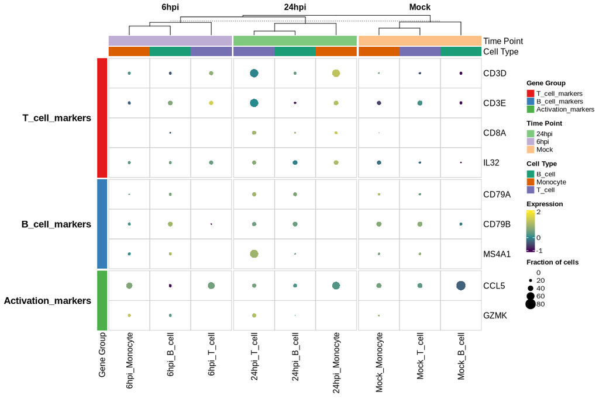

```r
# Publication-ready styling
heatmap_publication <- create_single_cell_complex_heatmap(
  seurat_object = seurat_obj,
  features = all_genes,
  gene_classification = gene_groups,
  group_by = "group",
  max_circle_size = 2.5,
  row_fontsize = 12,
  col_fontsize = 12,
  row_title_fontsize = 14,
  col_title_fontsize = 12,
  percentage_legend_title = "Fraction of cells",
  percentage_legend_labels = c("0", "20", "40", "60", "80"),
  legend_side = "right"
)
```

## Visual Element Control

This test demonstrates how to remove cell borders and column annotations for a cleaner look.

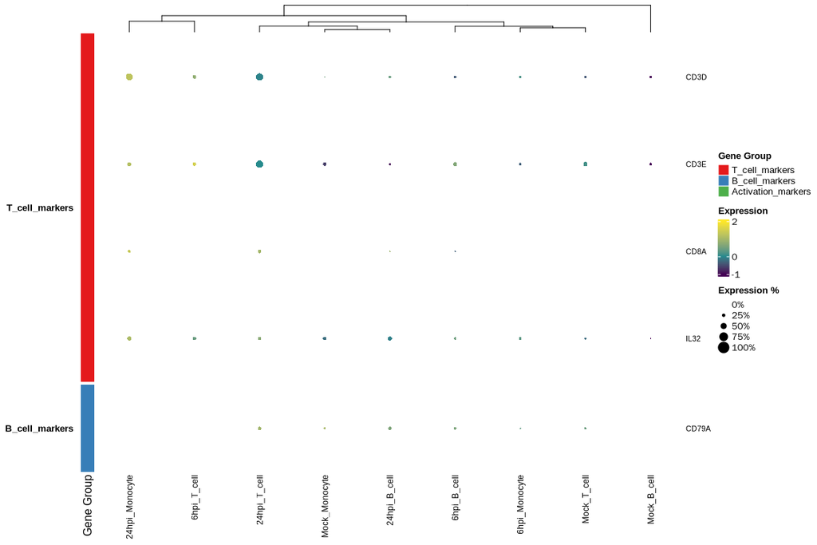

```r
heatmap_con <- create_single_cell_complex_heatmap(
  seurat_object = seurat_obj,
  features = features,
  gene_classification = gene_groups,
  group_by = "group",

  # NEW: Visual control parameters
  show_cell_borders = FALSE,
  show_column_annotation = FALSE,

  # Other parameters for a clean plot
  split_by = "none",
  cluster_cells = TRUE
)
```

## Gene Name Mapping

This test shows how to replace default gene names (e.g., symbols) with custom labels on the y-axis.

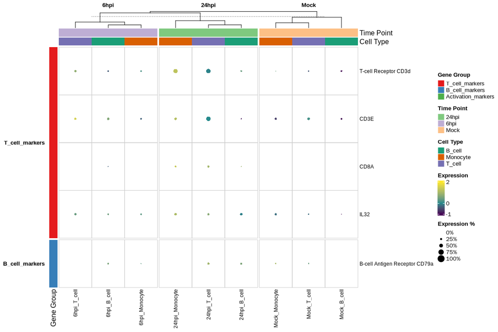

```r
# Create a mapping for a subset of genes
gene_mapping <- c(
  "CD3D" = "T-cell Receptor CD3d",
  "CD79A" = "B-cell Antigen Receptor CD79a",
  "GZMK" = "Granzyme K",
  "NKG7" = "Natural Killer Cell Granule Protein 7"
)

heatmap_map <- create_single_cell_complex_heatmap(
  seurat_object = seurat_obj,
  features = features,
  gene_classification = gene_groups,
  group_by = "group",

  # NEW: Gene name mapping
  gene_name_mapping = gene_mapping,

  row_fontsize = 9
)
```

## Clustering Control

You can control clustering behavior for both genes and cells:

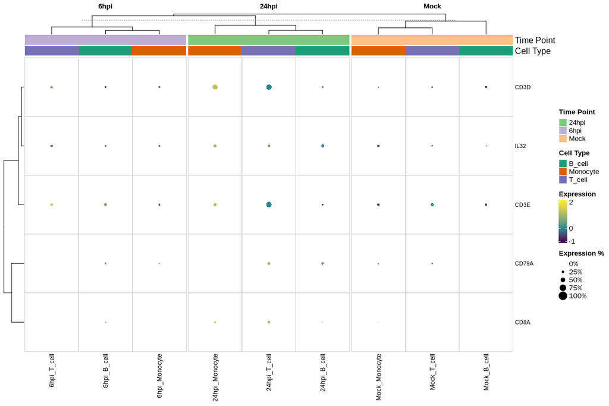

```r
# Custom clustering
heatmap_clustering <- create_single_cell_complex_heatmap(
  seurat_object = seurat_obj,
  features = features,
  group_by = "group",
  cluster_cells = TRUE,
  cluster_features = TRUE,
  clustering_distance_rows = "pearson",
  clustering_method_rows = "ward.D2",
  clustering_distance_cols = "euclidean",
  clustering_method_cols = "complete"
)
```

# Different Use Cases

## Case 1: Time Course Analysis

For time course experiments, focus on temporal patterns:

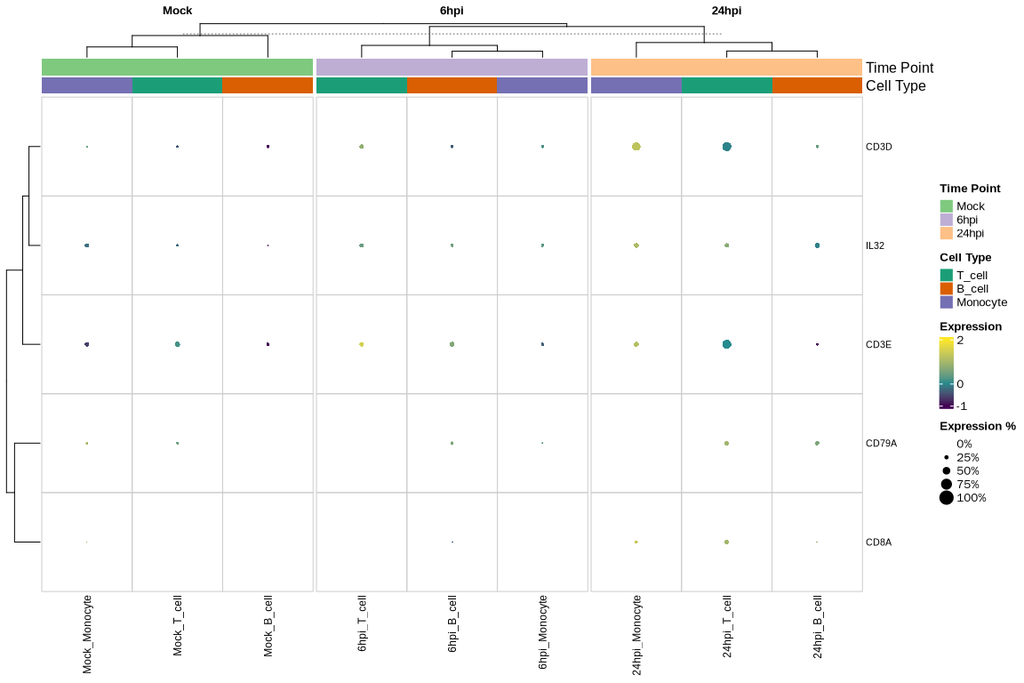

```r
# Time course focused analysis
heatmap_time <- create_single_cell_complex_heatmap(
  seurat_object = seurat_obj,
  features = features,
  group_by = "group",
  time_points_order = c("Mock", "6hpi", "24hpi"),
  cell_types_order = c("T_cell", "B_cell", "Monocyte"),
  split_by = "time",
  show_celltype_annotation = TRUE,
  show_time_annotation = TRUE
)
```

## Case 2: Cell Type Comparison

For cell type-focused analysis:

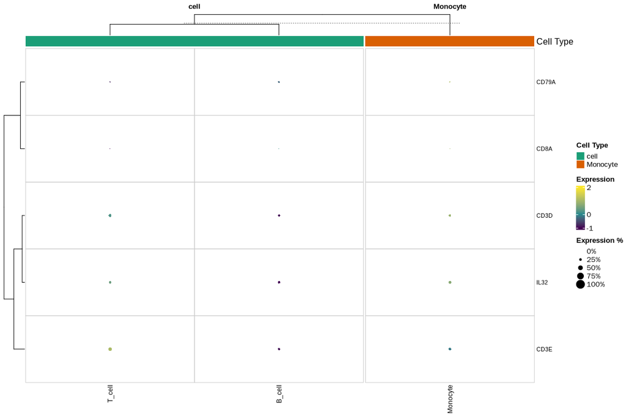

```r
# Cell type focused analysis
heatmap_celltype <- create_single_cell_complex_heatmap(
  seurat_object = seurat_obj,
  features = features,
  group_by = "celltype",
  split_by = "celltype",
  show_time_annotation = FALSE,
  show_celltype_annotation = TRUE
)
```

## Case 3: Simple Expression Analysis

For basic expression visualization without grouping:

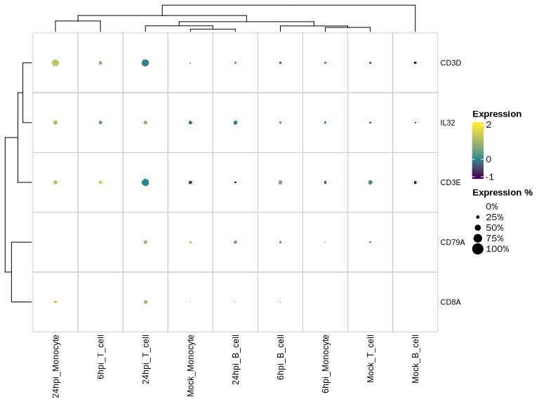

```r
# Simple analysis
heatmap_sample <- create_single_cell_complex_heatmap(
  seurat_object = seurat_obj,
  features = features,
  gene_classification = NULL,  # No gene grouping
  group_by = "group",
  show_time_annotation = FALSE,
  show_celltype_annotation = FALSE,
  split_by = "none"
)
```

# Comprehensive Example

This final example combines several new and existing features to create a highly customized, publication-ready plot.

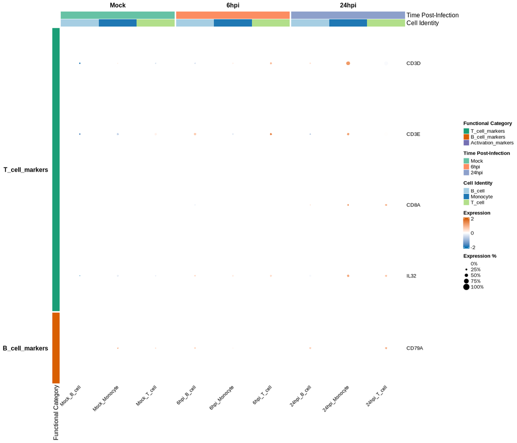

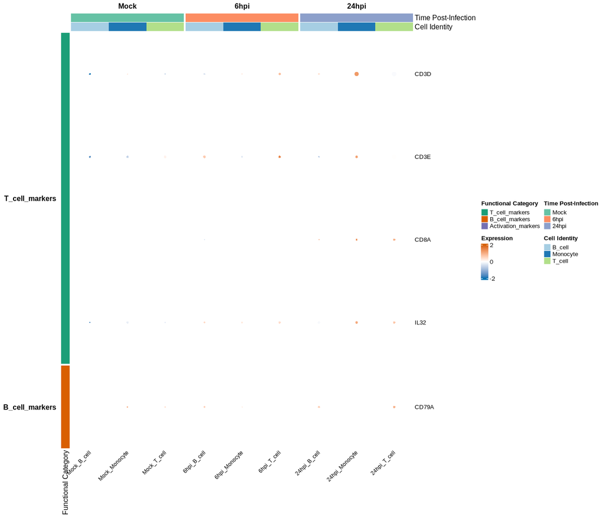

```r
create_single_cell_complex_heatmap(
  seurat_object = seurat_obj,
  features = features,
  gene_classification = gene_groups,
  group_by = "group",
  time_points_order = c("Mock", "6hpi", "24hpi"),

  # --- New Features ---
  gene_group_title = "Functional Category",
  time_point_title = "Time Post-Infection",
  cell_type_title = "Cell Identity",
  show_cell_borders = TRUE,
  cell_border_color = "white",
  gene_name_mapping = c("MS4A1" = "CD20"),

  # --- Color Customization ---
  color_range = c(-2, 0, 2),
  color_palette = c("#0072B2", "white", "#D55E00"), # Colorblind-friendly
  gene_color_palette = "Dark2",
  time_color_palette = "Set2",
  celltype_color_palette = "Paired",

  # --- Layout and Font ---
  row_fontsize = 10,
  col_fontsize = 9,
  row_title_fontsize = 12,
  col_title_fontsize = 12,
  col_name_rotation = 45,
  legend_side = "right",
  merge_legends = TRUE,

  # --- Clustering and Splitting ---
  cluster_features = FALSE, # Rows are already grouped
  cluster_cells = FALSE,    # Columns are already grouped
  split_by = "time"
)
```

# Working with Helper Functions

The package provides helper functions for step-by-step analysis:

## Step 1: Prepare Expression Matrices

```r
# Prepare matrices
matrices <- prepare_expression_matrices(
  seurat_object = seurat_obj,
  features = features,
  group_by = "group",
  idents = NULL  # Use all groups
)

# Check the structure
dim(matrices$exp_mat)
```

```
#> [1] 5 9
```

```r
dim(matrices$percent_mat)
```

```
#> [1] 5 9
```

```r
head(matrices$dotplot_data)
```

```
#>         avg.exp pct.exp features.plot             id avg.exp.scaled
#> CD3D  105.56974   25.00          CD3D   24hpi_B_cell     0.40882740
#> CD3E   27.84701   18.75          CD3E   24hpi_B_cell    -0.90555550
#> CD8A   20.66799   12.50          CD8A   24hpi_B_cell     0.91030585
#> IL32   70.30069   37.50          IL32   24hpi_B_cell    -0.07758342
#> CD79A  56.25748   31.25         CD79A   24hpi_B_cell     0.58606789
#> CD3D1 192.27796   62.50          CD3D 24hpi_Monocyte     1.25892500
```

## Step 2: Create Gene Annotations

```r
# Create gene annotations
if (!is.null(gene_groups)) {
  gene_ann <- create_gene_annotations(
    exp_mat = matrices$exp_mat,
    percent_mat = matrices$percent_mat,
    gene_classification = gene_groups,
    color_palette = "Set1"
  )

  # Check results
  dim(gene_ann$exp_mat_ordered)
  levels(gene_ann$annotation_df$GeneGroup)
}
```

```
#> [1] "T_cell_markers"     "B_cell_markers"     "Activation_markers"
```

## Step 3: Create Cell Annotations

```r
# Create cell annotations
cell_ann <- create_cell_annotations(
  exp_mat = matrices$exp_mat,
  percent_mat = matrices$percent_mat,
  time_points_order = c("Mock", "6hpi", "24hpi"),
  cell_types_order = c("T_cell", "B_cell", "Monocyte"),
  show_time_annotation = TRUE,
  show_celltype_annotation = TRUE
)

# Check results
dim(cell_ann$exp_mat_ordered)
```

```
#> [1] 5 9
```

```r
head(cell_ann$annotation_df)
```

```
#>              id Time Point Cell Type
#> 1   Mock_T_cell       Mock    T_cell
#> 2   Mock_B_cell       Mock    B_cell
#> 3 Mock_Monocyte       Mock  Monocyte
#> 4   6hpi_T_cell       6hpi    T_cell
#> 5   6hpi_B_cell       6hpi    B_cell
#> 6 6hpi_Monocyte       6hpi  Monocyte
```

# Saving and Exporting

You can save plots directly from the function:

```r
# Save plot to file
heatmap_saved <- create_single_cell_complex_heatmap(
  seurat_object = seurat_obj,
  features = features,
  gene_classification = gene_groups,
  group_by = "group",
  save_plot = "my_heatmap.png",
  plot_width = 12,
  plot_height = 10,
  plot_dpi = 300
)
```

# Tips and Best Practices

## 1. Data Preparation

- Ensure your metadata columns are properly formatted
- Use consistent naming conventions for time points and cell types
- Consider the number of features - too many can make the plot cluttered

## 2. Color Selection

- Use diverging color palettes for expression data
- Ensure sufficient contrast for accessibility
- Consider colorblind-friendly palettes

## 3. Performance Optimization

- For large datasets, consider subsetting cells or using representative clusters
- Reduce visual complexity with smaller circle sizes and fonts
- Use `merge_legends = TRUE` for cleaner layouts

## 4. Publication Guidelines

- Use high DPI (300+) for publication figures
- Ensure font sizes are readable in the final format
- Include scale bars and legends
- Consider splitting complex plots into multiple panels

# Troubleshooting

## Common Issues

1. **“Features not found”**: Check that gene names match exactly with your Seurat object
2. **“group_by column not found”**: Verify the metadata column name exists
3. **Empty heatmap**: Check that your `idents` parameter includes valid groups
4. **Clustering errors**: Ensure you have enough features for clustering algorithms

## Getting Help

If you encounter issues:

1. Check the function documentation: `?create_single_cell_complex_heatmap`
2. Review the examples in this vignette
3. File an issue on GitHub: https://github.com/FanXuRong/SingleCellComplexHeatMap/issues